# A guide to Bayesian proportion tests with R and {brms}

Using data from the UK Public Opinion of Forestry 2023 survey

Forest Research

Author

Si Maxwell

Published

1 September 2023

# Introduction

This report is a development opportunity for me and a guide for others to better understand Bayesian inference. In it I explore Bayesian proportion tests in R using the {brms} package and data from the [Public Opinion of Forestry 2023: UK](https://www.forestresearch.gov.uk/tools-and-resources/statistics/statistics-by-topic/public-opinion-of-forestry/) survey, conducted by YouGov on behalf of Forest Research. The survey asked 11,055 adults (aged 16+) in the UK a range of questions on forestry and forestry-related issues. Here we will explore the results of two questions from the survey: the proportion of respondents who visited woodland in the last few years, and the proportion of respondents that support new woodland creation (afforestation) in response to the threat of climate change.

The report is heavily (heavily!) based on the fantastic blog post [A guide to Bayesian proportion tests with R and {brms}](https://www.andrewheiss.com/blog/2023/05/15/fancy-bayes-diffs-props/) by Andrew Heiss, assistant professor at Georgia State University (published 15 May 2023). Andrew’s blog was inspired by a [blog post](https://www.sumsar.net/blog/2014/06/bayesian-first-aid-prop-test/) and R package by data scientist Rasmus Bååth (published 27 June 2014).

# Setup

The first thing we need to do is load all the necessary packages for the analysis. Note that {ggGSS} is a personal, in-house package for producing data visualisations that match [Government Statistical Service and Analysis Function guidance](https://analysisfunction.civilservice.gov.uk/policy-store/data-visualisation-charts/):

```r
library(tidyverse)
library(scales)
library(glue)
library(gt)
library(brms)
library(tidybayes)
library(ggdist)
library(ggGSS) # devtools::install_github("simaxwell/ggGSS")
library(ggpattern)
library(parameters)
```

Second, create a handy function for formatting percent point differences in plots:

```r
label_pp <- label_number(accuracy = 1,
                         scale = 100,
                         suffix = " pp")
```

And third, set the global Stan parameters:

```r
CHAINS <- 4
ITER <- 2000
WARMUP <- 1000
BAYES_SEED <- 1234
```

# Data wrangling and exploration

To explore the results from the survey we need to load in the data. As both data sets are nice and small, it’s easy enough to write it out manually. For reference, the data come from the [detailed spreadsheet supplied by YouGov](https://www.forestresearch.gov.uk/tools-and-resources/statistics/statistics-by-topic/public-opinion-of-forestry/), the market research company that conducted the survey on behalf of Forest Research.

```r
q1_raw <- tribble(
  ~gender, ~n, ~total,
  "Female", 4295.632, 5693.3235,
  "Male", 3890.773, 5361.675
) |>
  mutate(across(where(is.numeric), ~round(.x, 0)))
```

```r
q2_raw <- tribble(
  ~support, ~male, ~female,
  "Strongly agree", 2466.67, 2752.2,
  "Tend to agree",  1946.04, 2074.11,
  "Neither agree nor disagree", 677.33, 583.91,
  "Tend to disagree", 101.52, 84.49,
  "Strongly disagree", 54.41,   34.31,
  "Don't know", 115.71, 164.31
  ) |>
  mutate(across(where(is.numeric), ~round(.x, 0)))
```

Note that I use the weighted totals which means the results more accurately reflect the socio-demographic structure of the British population. The `mutate` call rounds all numeric columns to whole numbers (integers) as counts are needed for the models.

# The questions

The aim of this article is to illustrate the logic of Bayesian proportion tests using data from the Public Opinion of Forestry 2023: UK survey. To do this we will explore three research questions:

1. Is the proportion of women that visited woodland in the last few years higher than the proportion of men?
2. Is there a difference between the proportion of men and women that support afforestation as a climate change mitigation strategy?
3. Does support for afforestation vary among the UK population?

The first question we are going to explore is labelled KFW_Q1a in the YouGov spreadsheet. The question asked to all respondents was:

> In the last few years have you ever visited forests or woodlands for walks, picnics or other recreation?

Respondents could select one of two options:

1. Yes, I have, or
2. No, I haven’t.

For analysis 1 we will look at the proportion that answered “Yes, I have”.

The second question we are going to explore is labelled SFW_Q14_2 in the YouGov spreadsheet. All respondents were asked the following question:

> Thinking about managing UK forests and woodlands in response to climate change, to what extent do you agree or disagree with the following statement: “A lot more trees should be planted.”

Respondents were given six possible options:

- Strongly agree,
- Tend to agree,
- Neither agree nor disagree,
- Tend to disagree,
- Strongly disagree, and
- Don’t know.

With this question we are going to look at both the difference between men and women and among the population as a whole.

In order to reduce the number of possible answers and make the analysis simpler, the data have been transformed. First, I have collapsed 4 answers into 2 (in order to explore net support, i.e., all those that agree/disagree irrespective of the strength of feeling) and renamed one. Second, “don’t know” responses have been removed (after the calculation of the proportions).

The new options are:

- Agree = “strongly agree” + “tend to agree”
- Neither = “Neither agree nor disagree”
- Disagree = “strongly disagree” + “tend to disagree”

For analysis 2, we will look at the difference between men and women that answered “agree”; for analysis 3, we will look at the difference between “agree”, “neither” and “disagree” for all respondents.

# Analysis 1: woodland engagement among men and women

For our first question, we want to know if there is a substantial difference in the proportion of woodland visitors that are male and the proportion of woodland visitors that are female, or whether the difference between the proportions is zero (highlighted blue in Table 1).

Table 1: Contingency table showing the proportion of men and women that visited woodland in the last few years, UK, 2023

| Gender | Proportion |
| --- | --- |
| Female | 75.5% (4,296 of 5,693) |
| Male | 72.6% (3,891 of 5,362) |

Source: Public Opinion of Forestry 2023: UK survey. Crown copyright © Forest Research (2023).

In formal mathematical notation, we will call this the estimand $\theta$, which is the difference between the two proportions:

$$\theta = \pi_{\text{woodland visitor}_{\text{female}}} - \pi_{\text{woodland visitor}_{\text{male}}}$$

Before we begin our Bayesian analysis, let’s take a look at the classical frequentist way of performing and interpreting proportion tests in R.

## Classical frequentist way

In classical frequentist statistics we do not test the alternative hypothesis (in this case that there is a difference between the proportion of men and woman that visited woodland in the last few years). Instead, we test the null hypothesis (in this case that there is no difference between the proportions). If we reject the null hypothesis this lends support to the alternative hypothesis but we do not explicitly test the alternative hypothesis in the frequestist paradigm (thankfully we do in Bayesian statistics - more on that in the next section).

Written out in formula notation, our null hypothesis is that:

$$\theta = 0$$

To test the null hypothesis we will use R’s `prop.test()` function. Our task here is to calculate a test statistic (in this case $\chi^2$) for $\theta$, determine the probability of seeing that statistic in a world where $\theta$ is 0 and infer whether the value we see could plausibly fit in a world where the null hypothesis is true.

We need to pass `prop.test()` a 2-column matrix with the number of people that visited woodland (`n`) and the number of people that did not visit woodland (`n_didnt`). To do this we first need to subtract `n` from `total`, remove the `gender` and `total` columns and convert to a matrix.

```r
q1_matrix <- q1_raw |>
  mutate(n_didnt = total - n) |>
  select(-c(gender,
            total)) |>
  as.matrix()
```

We can now pass `q1_matrix` to `prop.test()`:

```r
prop.test(q1_matrix)
```

```
    2-sample test for equality of proportions with continuity correction

data:  q1_matrix
X-squared = 11.894, df = 1, p-value = 0.0005631
alternative hypothesis: two.sided
95 percent confidence interval:
 0.01241015 0.04548757
sample estimates:
   prop 1    prop 2
0.7546109 0.7256621
```

This tells us that we have performed a “2-sample test for equality of proportions with continuity correction”.

We have proportions that are the same as in Table 1 (75.5% / 72.6%) and the 95% confidence interval for the difference. R doesn’t show us the difference in proportions but the `parameters()` function from the {parameters} package will (Table 2).

```r
prop.test(q1_matrix) |>
  model_parameters()
```

Table 2: Summary results from the 2-sample test for equality of proportions

| Proportion | Difference | CI low | CI high | Χ<sup>2</sup> | p | Method |
| --- | --- | --- | --- | --- | --- | --- |
| 75.46% / 72.57% | 2.89% | 1.24% | 4.55% | 11.89 | 5.63 × 10<sup>−4</sup> | 2-sample test for equality of proportions |

CI: 95% confidence interval.

We have a $\chi^2$ statistic of 11.89 which is statistically significant. In a hypothetical world where there’s no difference in the proportions, the probability of seeing a difference of at least 2.89 percentage points is small ($p < 0.001$). We, therefore, have enough evidence to confidently reject the null hypothesis and declare that the proportions are not the same. With the confidence interval, we can say with 95% confidence that the interval 1.24 pp to 4.55 pp contains the true population parameter.

Let’s leave the frequentist paradigm behind.

## Bayesian way with {brms}

We have a situation where a subset of the UK population were asked if they have visited woodland in the last few years. Each respondent could either answer yes or no. This question was then asked independently to all 11,055 respondents, with each answering either yes or no.

The official statistical term for this kind of data-generating processes (a bunch of independent trials with some probability of success) is a binomial distribution. The most popular example is flipping a coin (where each flip results in either heads or tails). It is defined by three parameters:

$$y \sim \operatorname{Binomial}(n, \pi)$$

Where:

1. $y$ = number of successes: in our case, the number of respondents who visited woodland in the last few years (`n`).
2. $\pi$ = probability of success: the probability that someone visited woodland in the last few years (this is the thing we want to model for each gender).
3. $n$ = number of trials: in our case, the total number of respondents (`total`).

We are interested in the probability of a “success” (i.e., $\pi$), which is the number of successes divided by the total number of trials:

$$\pi = \frac{\text{Number of successes}}{\text{Number of trials}}$$

Which can also be expressed:

$$\pi = \frac{\text{Number of successes}}{\text{(Number of successes} + \text{Number of failures)}}$$

Expressed in terms of our data on woodland visitors, the equation becomes:

$$\pi = \frac{\text{Number of woodland visitors}}{\text{Number of respondents}}$$

Similarly, we can split the denominator into woodland visitors and non-visitors as follows:

$$\pi = \frac{\text{Number of woodland visitors}}{(\text{Number of woodland visitors} + \text{Number of non-visitors)}}$$

It is $\pi$ that we are going to estimate. We are going to model $\pi$ using the beta-binomial distribution. The beta-binomial distribution is the binomial distribution in which the probability of success at each of $n$ trials is not fixed but randomly drawn from a beta distribution. It is bound by the interval [0, 1], which is ideal because $\pi$ is a proportion somewhere between 0 and 1 (i.e., 0% and 100%). (This is set out formulaically later.) The beta distribution is defined by two positive shape parameters: $\alpha$ and $\beta$, where $\alpha$ and $\beta$ correspond to the number of successes (answered “yes”) and failures (answered “no”), respectively:

$$\pi = \frac{\alpha}{\alpha + \beta}$$

With these shape parameters we can create any percentage/proportion we want in order to model $\pi$. In addition, we can control for the uncertainty of the distribution by changing the size of the parameters. For instance, if we think that there is a 60% chance of some event occuring, this could be represented by $\alpha = 3$ and $\beta = 2$, since $\frac{3}{3+2} = 0.6$. We could also write it as $\alpha = 30$ and $\beta = 20$, since $\frac{30}{30+20} = 0.6$ too. Both are centred at 60% but Beta(30, 20) is a lot narrower than Beta(3, 2) (Figure 1).

Figure 1: Beta(3, 2) and Beta(30, 20) distributions

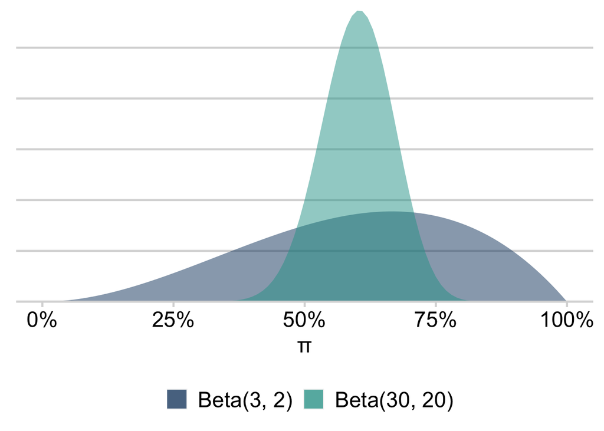

```r
ggplot() +
  stat_function(fun = ~dbeta(., 3, 2), geom = "area",
                aes(fill = "Beta(3, 2)"), alpha = 0.5) +
  stat_function(fun = ~dbeta(., 30, 20), geom = "area",
                aes(fill = "Beta(30, 20)"), alpha = 0.5) +
  scale_x_continuous(labels = label_percent()) +
  scale_y_continuous(expand = expansion(mult = c(0, 0))) +
  scale_fill_gss_d() +
  labs(x = "π",
       y = NULL,
       fill = NULL) +
  theme_gss(axis.text.y = element_blank(),
            legend.position = "bottom",
            tick_mark = "x",
            font_size = 18)
```

We have already seen the data and know that the proportion of woodland visitors is around 73% for men and 76% for women. But let’s pretend that we haven’t seen the data and all our prior knowledge is based on the 2021 Public Opinion of Forestry survey. In the previous survey, 69% of respondents reported visiting woodland in the last few years. To make the maths easier, let’s say 70% instead. This implies something like a Beta(7, 3) distribution (since $\frac{7}{7+3} = 0.7$). We could narrow this down by using the Beta(70, 30) distribution, but leaving the prior wide like this allows for more possible responses (Figure 2).

Figure 2: Beta(7, 3) distribution

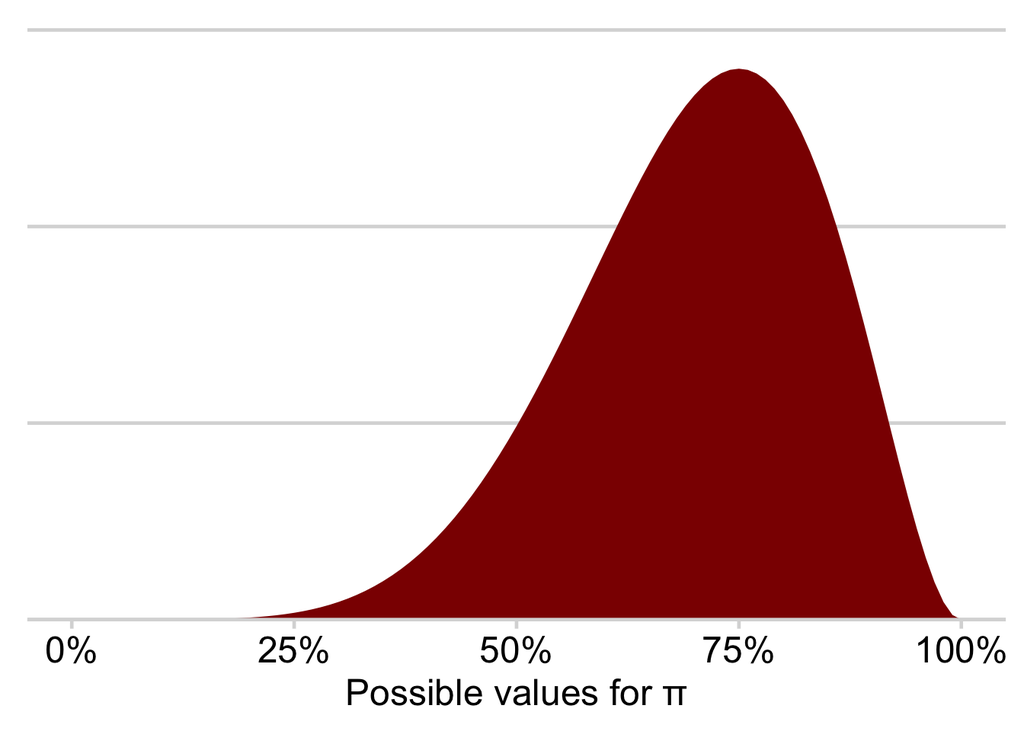

```r
ggplot() +
  stat_function(fun = ~dbeta(., 7, 3),
                geom = "area",
                fill = "#8C0000") +
  scale_x_continuous(labels = label_percent()) +
  scale_y_continuous(expand = expansion(mult = c(0, 0.02)),
                     limits = c(0, 3)) +
  labs(x = "Possible values for π",
       y = NULL,
       fill = NULL) +
  theme_gss(axis.text.y = element_blank(),
            tick_mark = "x",
            font_size = 18)
```

Instead of using the shape parameters $\alpha$ and $\beta$, {brms} uses mean ($\mu$) and precision or overdispersion ($\phi$) parameterisation for the beta-binomial family. Fortunately, the conversion is simple:

$$\begin{aligned}
\text{Shape 1:} && \alpha &= \mu \times \phi \\
\text{Shape 2:} && \beta &= (1 - \mu) \times \phi
\end{aligned}$$
This means that:

$$\begin{aligned}
\text{Mean:} && \mu &= \frac{\alpha}{\alpha + \beta} \\
\text{Precision:} && \phi &= \alpha + \beta
\end{aligned}$$

Plugging in our numbers we get the following values for the priors:

$$\begin{aligned}
\text{Mean:} && \mu &= \frac{7}{(7 + 3)} \\
&& &= \frac{7}{10} \\
&& &= 0.7 \\
\text{Precision:} && \phi &= \alpha + \beta \\
&& &= 7 + 3 \\
&& &= 10
\end{aligned}$$

Figure 3: Exponential(1/1000) distribution

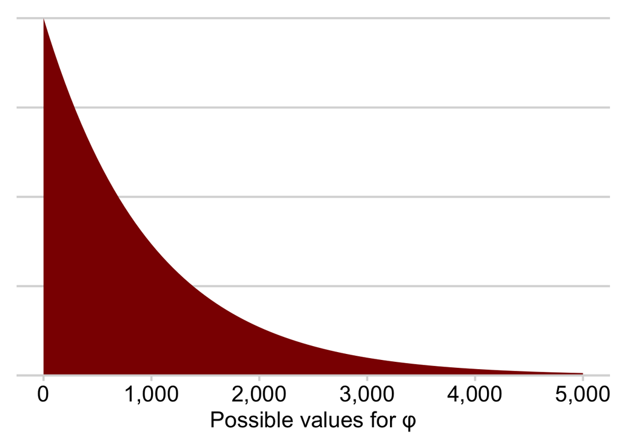

```r
ggplot() +
  stat_function(fun = ~dexp(., 0.001),
                geom = "area",
                fill = "#8C0000") +
  scale_x_continuous(label = comma_format(),
                     limits = c(0, 5000)) +
  scale_y_continuous(expand = expansion(mult = c(0, 0.02))) +
  labs(x = "Possible values for φ",
       y = NULL,
       fill = NULL) +
  theme_gss(axis.text.y = element_blank(),
            tick_mark = "x",
            font_size = 18)
```

Okay, so with our Beta(7, 3) prior, we now have all the information we need to specify the formal model of the data generating process for our estimand without a null hypothesis in sight:

$$\begin{aligned}
&\ \textbf{Estimand} \\
\theta =&\ \pi_{\text{woodland visitor}_\text{female}} - \pi_{\text{woodland visitor}_\text{male}} \\[10pt]
&\ \textbf{Beta-binomial model for female} \\
y_{n \text{ woodland visitor}_\text{female}} \sim&\ \operatorname{Binomial}(n_{\text{total}_\text{female}}, \pi_{\text{woodland visitor}_\text{female}}) \\
\pi_{\text{woodland visitor}_\text{female}} \sim&\ \operatorname{Beta}(\alpha_\text{female}, \beta_\text{female}) \\[10pt]
&\ \textbf{Beta-binomial model for male} \\
y_{n \text{ woodland visitor}_\text{male}} \sim&\ \operatorname{Binomial}(n_{\text{total}_\text{male}}, \pi_{\text{woodland visitor}_\text{male}}) \\
\pi_{\text{woodland visitor}_\text{male}} \sim&\ \operatorname{Beta}(\alpha_\text{male}, \beta_\text{male}) \\[10pt]
&\ \textbf{Priors} \\
\alpha_\text{female}, \alpha_\text{male} =&\ 7 \\
\beta_\text{female}, \beta_\text{male} =&\ 3
\end{aligned}$$
Let’s jump into {brms}.

### Setting priors

The {brms} package has a handy function for identifying the parameters we can set (i.e., our priors). By passing our equation, data set and family to the `get_prior` function we can see which parameters can be modeled and {brms}’s defaults:

```r
get_prior(formula = bf(n | trials(total) ~ 0 + gender),
          data = q1_raw,
          family = beta_binomial(link = "identity",
                                 link_phi = "identity"))
```

```
             prior class         coef group resp dpar nlpar lb ub       source
            (flat)     b                                               default
            (flat)     b genderFemale                             (vectorized)
            (flat)     b   genderMale                             (vectorized)
 gamma(0.01, 0.01)   phi                                     0         default
```

We get three useful pieces of information from the output of the `get_prior` function:

1. The default priors for gender are “flat” (i.e., all values are equally likely). We are going to change this using our *a priori* knowledge.
2. Using the `coef` argument, we can set separate priors for the male and female woodland visitor proportions (where each will require a unique `set_prior` call). Doing that would be overkill here. Handily, setting `class = "b"` (i.e., population-level “fixed” effect) will ensure the same prior for each gender.
3. The default prior for $\phi$ (the precision parameter) is $\text{Gamma}(0.01, 0.01)$.

Let’s set our priors and save them as an object called `prior_q1`. Note `lb` and `ub` refer to the lower and upper bounds, respectively:

```r
prior_q1 <- c(
  set_prior("beta(7, 3)", class = "b", lb = 0, ub = 1),
  set_prior("exponential(0.001)", class = "phi", lb = 0)
)
```

Now we have set our priors, let’s run our first Bayesian model:

### Running the model

```r
q1_beta_binomial_model <- brm(
  bf(n | trials(total) ~ 0 + gender),
  data = q1_raw,
  family = beta_binomial(link = "identity",
                         link_phi = "identity"),
  prior = prior_q1,
  init = 0.1,
  chains = CHAINS,
  warmup = WARMUP,
  iter = ITER,
  seed = BAYES_SEED,
  refresh = 0
)
```

It can take a little while to compile the Stan program. But running these small models is pretty quick.

The posterior distributions of the proportion of men and women that visited woodland in the last few years is shown in Figure 4 and Table 3.

Figure 4: Posterior distributions of the proportion of **men** and **women** that visited woodland in the last few years

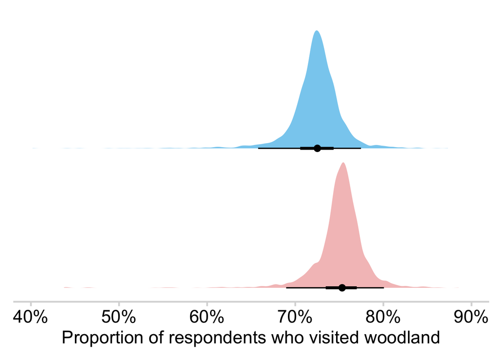

```r
q1_beta_binomial_model |>
  epred_draws(newdata = q1_raw) %>%
  mutate(.epred_prop = .epred / total) %>%
  ggplot(aes(x = .epred_prop, y = gender, fill = gender)) +
  stat_halfeye() +
  scale_x_continuous(expand = expansion(mult = c(0.04, 0.04)),
                     labels = label_percent(),
                     limits = c(0.4, 0.9)) +
  scale_y_discrete(expand = expansion(mult = c(0.1, 0.02))) +
  scale_fill_manual(values = c("#F4C2C2", "#89CFF0")) +
  labs(x = "Proportion of respondents who visited woodland",
       y = NULL) +
  theme_gss(grid = "none",
            tick_mark = "x",
            legend.position = "none",
            axis.line.x = element_line("#D9D9D9"),
            axis.text.y = element_blank(),
            font_size = 18)
```

```r
q1_diffs <- q1_beta_binomial_model %>%
  epred_draws(newdata = q1_raw) %>%
  mutate(.epred_prop = .epred / total) %>%
  ungroup() %>%
  mutate(gender = fct_relevel(gender, "Male")) %>%
  compare_levels(.epred_prop,
                 by = gender,
                 comparison = "pairwise")
```

Table 3: Number of woodland visitors and summary of the posterior distribution by gender

| Gender | Number of woodland visitors | Total number of respondents | Median of posterior distribution | Lower 95% credible interval | Upper 95% credible interval |
| --- | --- | --- | --- | --- | --- |
| Female | 4,296 | 5,693 | 75.3% | 69.0% | 80.1% |
| Male | 3,891 | 5,362 | 72.5% | 65.8% | 77.5% |

The posterior distribution of the difference in proportion of men and women that visited woodland in the last few years is shown in Figure 5 and Table 4.

Figure 5: Posterior distribution of the **difference** in proportions of men and women that visited woodland in the last few years

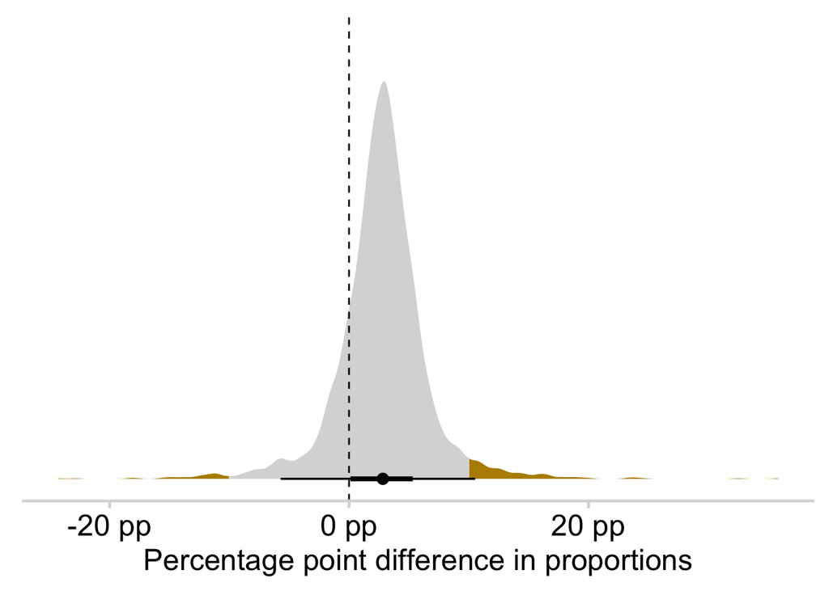

```r
q1_diffs |>
  ggplot(aes(x = .epred_prop, fill = stat(abs(x) > 0.1))) +
  stat_halfeye() +
  geom_vline(xintercept = 0, linetype = "dashed") +
  scale_x_continuous(labels = label_pp) +
  scale_fill_manual(values = c("#D9D9D9", "#B78C01")) +
  labs(x = "Percentage point difference in proportions",
       y = NULL) +
  theme_gss(grid = "none",
            tick_mark = "x",
            legend.position = "none",
            axis.line.x = element_line("#D9D9D9"),
            axis.text.y = element_blank(),
            font_size = 18)
```

Table 4 shows a summary of the posterior distribution.

Table 4: Posterior distribution of the difference in proportions of men and women that visited woodland in the last few years

|  | Difference | Lower 95% credible interval | Upper 95% credible interval | Proportion of posterior draws > 0 | Proportion of posterior draws outside ROPE |
| --- | --- | --- | --- | --- | --- |
| Female - Male | 2.8% | −5.7% | 10.5% | 84.0% | 3.7% |

ROPE: Region of Practical Equivalence. Data that fall within ROPE (-10 pp to +10 pp) are practically equivalent to zero.

### Conclusion

What’s our final answer to the question “Is the proportion of women that visited woodland in the last few years higher than the proportion of men?”?

In an official report or article, we could write something like this:

> In the UK, women are slightly more likely to have visited woodland in the last few years compared to men. In 2023, on average, 75.3% (between 69.0% and 80.1%) of women visited woodland in the last few years, compared to 72.5% (between 65.8% and 77.5%) of men. There is a 95% posterior probability that the difference between these proportions is between -5.7 and 10.5 percentage points, with a median of 2.8 percentage points.

We can use the `hypothesis` function in the {brms} package to verify this:

```r
hypothesis(q1_beta_binomial_model,
           "genderFemale > genderMale")
```

```
Hypothesis Tests for class b:
                Hypothesis Estimate Est.Error CI.Lower CI.Upper Evid.Ratio
1 (genderFemale)-(g... > 0     0.03      0.04    -0.03     0.08       5.27
  Post.Prob Star
1      0.84
---
'CI': 90%-CI for one-sided and 95%-CI for two-sided hypotheses.
'*': For one-sided hypotheses, the posterior probability exceeds 95%;
for two-sided hypotheses, the value tested against lies outside the 95%-CI.
Posterior probabilities of point hypotheses assume equal prior probabilities.
```

The output is verbose but in summary:

The evidence in favour of $\pi_{\text{woodland visitor}_{\text{female}}} > \pi_{\text{woodland visitor}_{\text{male}}}$ is 5.27 times greater than the evidence in favour of $\pi_{\text{woodland visitor}_{\text{male}}} > \pi_{\text{woodland visitor}_{\text{female}}}$.

# Analysis 2: support for new woodland creation among men and women

## Introduction

For this question, we will look at the difference in the proportions of men vs. women that support (net agree = “strongly agree” + “tend to agree”) more tree planting in response to the threat of climate change.

Let’s wrangle the data into the correct shape.

```r
wc_df <- q2_raw |>
  pivot_longer(cols = -support,
               names_to = "gender",
               values_to = "n") |>
  mutate(support = case_when(
    support == "Strongly agree" ~ "Agree",
    support == "Tend to agree" ~ "Agree",
    support == "Strongly disagree" ~ "Disagree",
    support == "Tend to disagree" ~ "Disagree",
    support == "Neither agree nor disagree" ~ "Neither",
    TRUE ~ support
  )) |>
  group_by(support, gender) |>
  summarise(n = sum(n)) |>
  ungroup() %>%
  group_by(support) |>
  group_modify(~ bind_rows(., summarize(., across(where(is.numeric), sum)))) |>
  ungroup() |>
  replace_na(list(gender = "total")) |>
  group_by(gender) |>
  mutate(total = sum(n),
         prop = n / total) |>
  ungroup() |>
  filter(support != "Don't know") |>
  mutate(support = fct_relevel(support, c("Agree", "Neither", "Disagree"))) |>
  arrange(support)
```

The results from the Public Opinion of Forestry 2023: UK survey are highlighted green in Table 5.

Table 5: Contingency table showing the proportion of men and women that support afforestation, UK, 2023

| Support | Female | Male | All respondents |
| --- | --- | --- | --- |
| Agree | 84.79% (4,826 of 5,692) | 82.30% (4,413 of 5,362) | 83.58% (9,239 of 11,054) |
| Neither | 10.26% (584 of 5,692) | 12.63% (677 of 5,362) | 11.41% (1,261 of 11,054) |
| Disagree | 2.07% (118 of 5,692) | 2.91% (156 of 5,362) | 2.48% (274 of 11,054) |

Source: Public Opinion of Forestry 2023: UK survey. Crown copyright © Forest Research (2023).

Our formal model can be written out as follows:

$$\begin{aligned}
&\ \textbf{Estimand} \\
\theta =&\ \pi_{\text{afforestation support}_\text{female}} - \pi_{\text{afforestation support}_\text{male}} \\[10pt]
&\ \textbf{Beta-binomial model for female} \\
y_{n \text{ afforestation support}_\text{female}} \sim&\ \operatorname{Binomial}(n_{\text{total}_\text{female}}, \pi_{\text{afforestation support}_\text{female}}) \\
\pi_{\text{afforestation support}_\text{female}} \sim&\ \operatorname{Beta}(\alpha_\text{female}, \beta_\text{female}) \\[10pt]
&\ \textbf{Beta-binomial model for male} \\
y_{n \text{ afforestation support}_\text{male}} \sim&\ \operatorname{Binomial}(n_{\text{total}_\text{male}}, \pi_{\text{afforestation support}_\text{male}}) \\
\pi_{\text{afforestation support}_\text{male}} \sim&\ \operatorname{Beta}(\alpha_\text{male}, \beta_\text{male}) \\[10pt]
&\ \textbf{Priors} \\
\alpha_\text{female}, \alpha_\text{male} =&\ 6 \\
\beta_\text{female}, \beta_\text{male} =&\ 2
\end{aligned}$$

For the remaining analyses, we’ll just get straight into the code.

First, we need to create our data set. Let’s filter for just those respondents that agree that a lot more trees should be planted and remove the rows with totals.

```r
q2_df <- wc_df |>
  filter(support == "Agree",
         gender %in% c("female", "male"))
```

By passing our formula, data set and family to `get_prior()` we can see {brms}’s default priors.

```r
get_prior(formula = bf(n | trials(total) ~ 0 + gender),
          data = q2_df,
          family = beta_binomial(link = "identity",
                                 link_phi = "identity"))
```

```
             prior class         coef group resp dpar nlpar lb ub       source
            (flat)     b                                               default
            (flat)     b genderfemale                             (vectorized)
            (flat)     b   gendermale                             (vectorized)
 gamma(0.01, 0.01)   phi                                     0         default
```

```r
prior_q2 <- c(
  set_prior("beta(6, 2)", class = "b", lb = 0, ub = 1),
  set_prior("exponential(0.001)", class = "phi", lb = 0)
)
```

```r
q2_beta_binomial_model <- brm(
  bf(n | trials(total) ~ 0 + gender),
  data = q2_df,
  family = beta_binomial(link = "identity",
                         link_phi = "identity"),
  prior = prior_q2,
  init = 0.1,
  chains = CHAINS,
  warmup = WARMUP,
  iter = ITER,
  seed = BAYES_SEED,
  refresh = 0
)
```

## Model results

Figure 6 shows the posterior distributions of the proportion of men and women that support afforestation as a climate change mitigation strategy.

Figure 6: Posterior distributions of the proportion of **men** and **women** that support afforestation

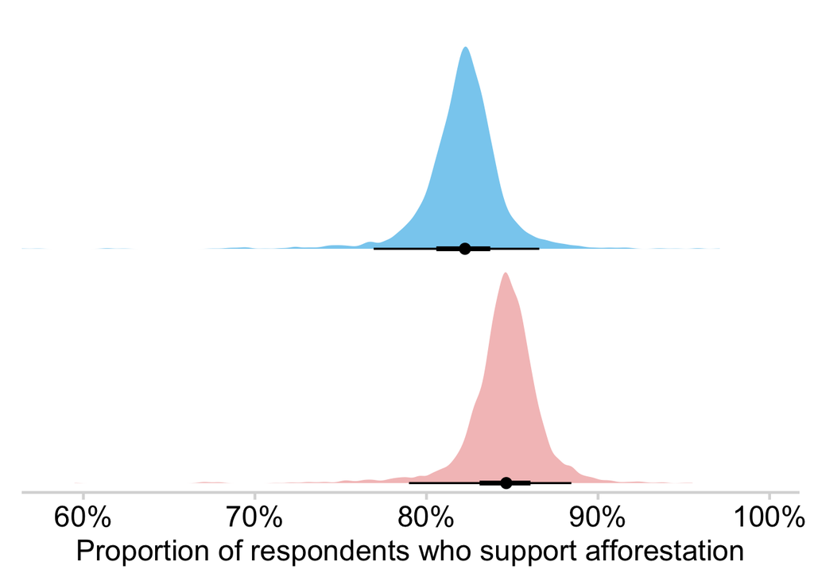

Again, let’s extract the draws and explore the difference in the proportions.

```r
q2_diffs <- q2_beta_binomial_model %>%
  epred_draws(newdata = q2_df) %>%
  mutate(.epred_prop = .epred / total) %>%
  ungroup() %>%
  mutate(gender = fct_relevel(gender, "male")) %>%
  compare_levels(.epred_prop,
                 by = gender,
                 comparison = "pairwise") |>
  ungroup()
```

Table 6: Number of tree planting supporters and summary of the posterior distribution by gender

| Gender | Number that support tree planting | Total number of respondents | Median of posterior distribution | Lower 95% credible interval | Upper 95% credible interval |
| --- | --- | --- | --- | --- | --- |
| Female | 4,826 | 5,692 | 84.7% | 79.0% | 88.4% |
| Male | 4,413 | 5,362 | 82.2% | 76.9% | 86.6% |

Figure 7 and Table 7 show the posterior distribution of the difference in proportions. The posterior distribution is shown in grey and gold: the area in grey falls within the Region of Practical Equivalence or ROPE (between -10 pp and +10 pp) where the difference is indistinguishable from zero; the area in gold is outside ROPE and can be thought of as being “significantly” different from zero.

Figure 7: Posterior distribution of the **difference** in proportions

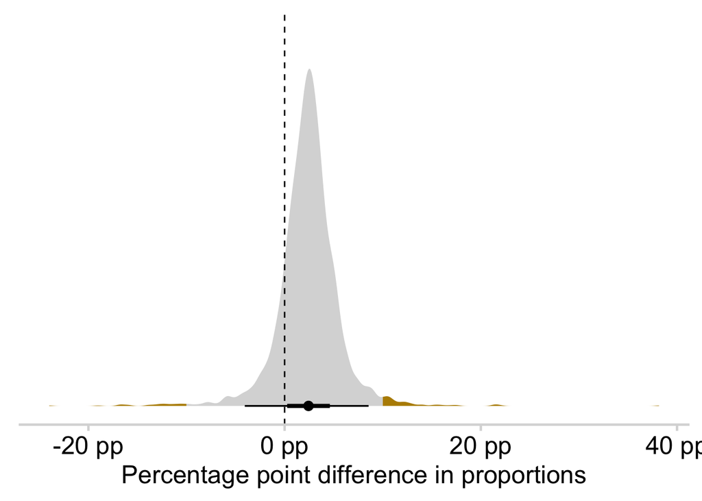

```r
q2_diffs |>
  ggplot(aes(x = .epred_prop, fill = stat(abs(x) > 0.1))) +
  stat_halfeye() +
  geom_vline(xintercept = 0, linetype = "dashed") +
  scale_x_continuous(labels = label_pp) +
  scale_fill_manual(values = c("#D9D9D9", "#B78C01")) +
  labs(x = "Percentage point difference in proportions",
       y = NULL) +
  theme_gss(grid = "none",
            tick_mark = "x",
            legend.position = "none",
            axis.line.x = element_line("#D9D9D9"),
            axis.text.y = element_blank(),
            font_size = 18)
```

Table 7: Posterior distribution of the difference in proportions

| Difference | Lower 95% credible interval | Upper 95% credible interval | Proportion of posterior draws > 0 | Proportion of draws outside ROPE |
| --- | --- | --- | --- | --- |
| 2.4% | −4.1% | 8.6% | 85.8% | 2.0% |

ROPE: Region of Practical Equivalence. Data that fall within ROPE (-10 pp to +10 pp) are practically equivalent to zero.

## Conclusion

We can summarise our findings from analysis 2 by saying:

> Women are slightly more likely to support tree planting than men in the UK. On average, 84.7% (between 79.0% and 88.4%) of women supported tree planting compared to 82.2% (between 76.9% and 86.6%) of men. There is a 95% posterior probability that the difference between these proportions is between -4.1 and 8.6 percentage points, with a median of 2.4 percentage points. While the difference is small, there is a 86% chance that the difference is greater than zero. However, only 1.4% of draws are both greater than zero and outside ROPE.

# Analysis 3: support for new woodland creation in the UK population

## Introduction

Lastly, for this question we will look at the pink highlighted cells in Table 5.

Again, we’ll call the estimand $\theta$ but this time we have three different versions of it:

$$\theta_{AN} = \pi_{\text{agree}} - \pi_{\text{neither}}$$

$$\theta_{AD} = \pi_{\text{agree}} - \pi_{\text{disagree}}$$

$$\theta_{ND} = \pi_{\text{neither}} - \pi_{\text{disagree}}$$

As we are interested in the population as a whole we need to filter for just the totals rows and remove the `gender` column.

```r
q3_df <- wc_df |>
  ungroup() |>
  filter(gender == "total") |>
  select(-gender) |>
  mutate(across(where(is.factor), as.character))
```

## Running the model

First, let’s explore…

```r
get_prior(formula = bf(n | trials(total) ~ 0 + support),
          data = q3_df,
          family = beta_binomial(link = "identity",
                                 link_phi = "identity"))
```

```
             prior class            coef group resp dpar nlpar lb ub
            (flat)     b
            (flat)     b    supportAgree
            (flat)     b supportDisagree
            (flat)     b  supportNeither
 gamma(0.01, 0.01)   phi                                        0
       source
      default
 (vectorized)
 (vectorized)
 (vectorized)
      default
```

…and then set our priors. Note that in this final example we use a Beta(1,1), i.e., a flat, prior where all possible values between 0% and 100% are equally likely. The precision parameter remains the same.

```r
prior_q3 <- c(
  set_prior("beta(1, 1)", class = "b", lb = 0, ub = 1),
  set_prior("exponential(0.001)", class = "phi", lb = 0)
)
```

## Model results

```r
q3_beta_binomial_model <- brm(
  bf(n | trials(total) ~ 0 + support),
  data = q3_df,
  family = beta_binomial(link = "identity",
                         link_phi = "identity"),
  prior = prior_q3,
  init = 0.1,
  chains = CHAINS,
  warmup = WARMUP,
  iter = ITER,
  seed = BAYES_SEED,
  refresh = 0
)
```

To make it easier to interpret, let’s set three different colours for agree, neither and disagree.

```r
col_agree <- "#2188a2"
col_neither <- "#4B5A20"
col_disagree <- "#cd6b61"
```

Figure 8 and Table 8 show the posterior distributions of the proportion of people that agree, neither agree nor disagree and disagree with more tree planting.

Figure 8: Posterior distributions of the proportion of people that **agree**, **neither agree nor disagree** and **disagree** with new woodland creation

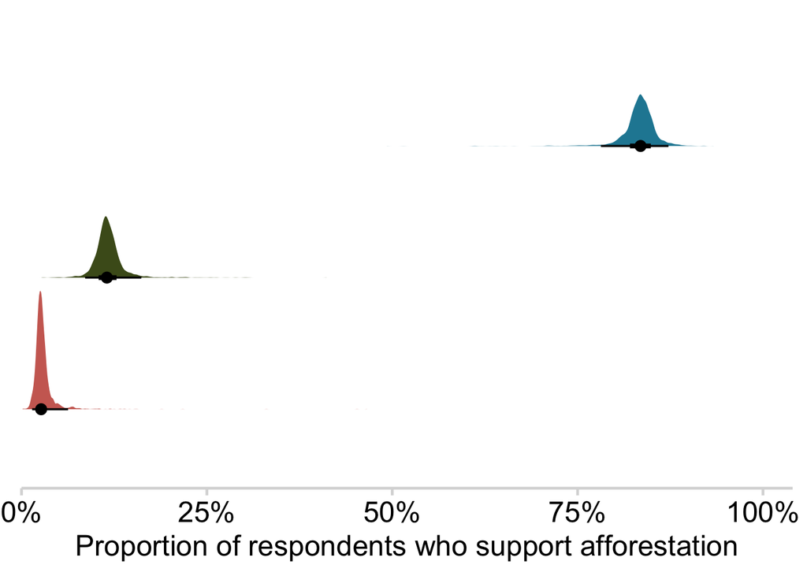

```r
q3_beta_binomial_model |>
  epred_draws(newdata = q3_df) %>%
  mutate(.epred_prop = .epred / total) %>%
  mutate(support = factor(support, levels = c("Agree",
                                              "Neither",
                                              "Disagree"))) |>
  ggplot(aes(x = .epred_prop, y = fct_rev(support), fill = support)) +
  stat_halfeye(show.legend = FALSE) +
  scale_x_continuous(expand = expansion(mult = c(0, 0.04)),
                     labels = label_percent(),
                     limits = c(0, 1)) +
  scale_fill_manual(values = c(col_agree, col_neither, col_disagree)) +
  labs(x = "Proportion of respondents who support afforestation",
       y = NULL) +
  theme_gss(grid = "none",
            tick_mark = "x",
            legend.position = "none",
            axis.line.x = element_line("#D9D9D9"),
            axis.text.y = element_blank(),
            font_size = 18)
```

```r
q3_beta_binomial_model |>
  epred_draws(newdata = q3_df) |>
  mutate(.epred_prop = .epred / total) |>
  group_by(support) %>%
  median_qi(.epred_prop) |>
  mutate(support = fct_reorder(support, c("Agree", "Neither", "Disagree"))) |>
  arrange(support) |>
  gt() |>
  cols_hide(c(".width", ".point", ".interval")) |>
  cols_label(support = "Support",
             .epred_prop = "Median of posterior distribution",
             .lower = "Lower 95% credible interval",
             .upper = "Upper 95% credible interval") |>
  fmt_percent(columns = c("support", ".epred_prop", ".lower", ".upper"),
              decimals = 1) |>
  opt_horizontal_padding(3) |>
  tab_footnote(footnote = "Source: Public Opinion of Forestry 2023: UK survey. Crown copyright © Forest Research (2023).") |>
  tab_options(column_labels.font.weight = "bold",
              row_group.font.weight = "bold")
```

Table 8: Summary of the posterior distribution by level of support for more tree planting

| Support | Median of posterior distribution | Lower 95% credible interval | Upper 95% credible interval |
| --- | --- | --- | --- |
| Agree | 83.5% | 78.1% | 87.2% |
| Neither | 11.5% | 8.6% | 16.2% |
| Disagree | 2.6% | 1.4% | 6.3% |

Source: Public Opinion of Forestry 2023: UK survey. Crown copyright © Forest Research (2023).

Figure 9 and Table 9 show the posterior distribution of the difference in proportions between agree, neither and disagree. Again, like Figure 7, the posterior distribution is coloured grey and gold to show the area inside and outside the Region of Practical Equivalence (ROPE), respectively.

Figure 9: Posterior distribution of the difference in proportions between those that agree, neither agree or disagree and disagree with more tree planting

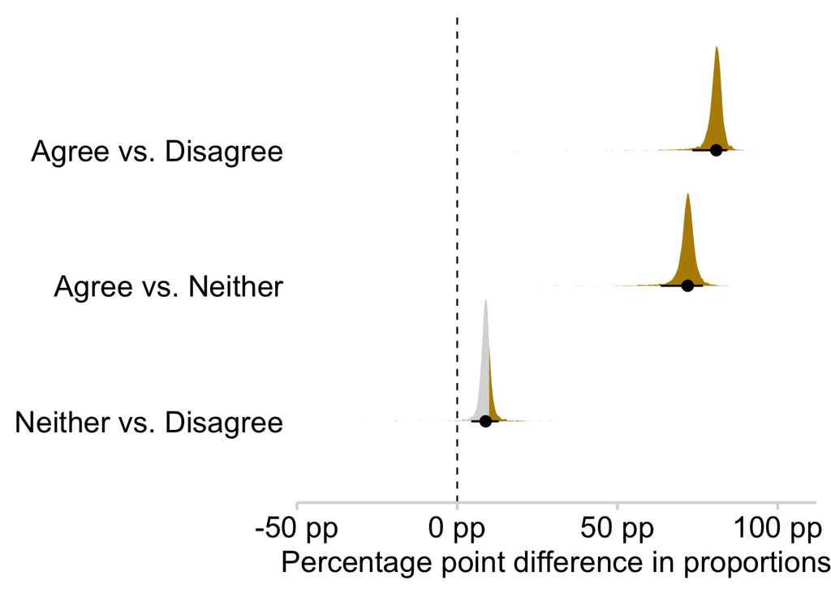

```r
q3_beta_binomial_diffs |>
  ggplot(aes(x = .epred_prop, y = fct_rev(support), fill = stat(abs(x) > 0.1))) +
  stat_halfeye() +
  geom_vline(xintercept = 0, linetype = "dashed") +
  scale_x_continuous(expand = expansion(mult = c(0, 0.08)),
                     labels = label_pp,
                     limits = c(-0.5, 1)) +
  scale_fill_manual(values = c("#D9D9D9", "#B78C01")) +
  labs(x = "Percentage point difference in proportions",
       y = NULL) +
  theme_gss(grid = "none",
            tick_mark = "x",
            legend.position = "none",
            axis.line.x = element_line("#D9D9D9"),
            font_size = 18)
```

```r
q3_beta_binomial_diffs |>
  summarize(median = median_qi(.epred_prop),
            pct_gt_0 = sum(.epred_prop > 0) / n(),
            pct_rope = sum(abs(.epred_prop) > 0.1) / n()) %>%
  unnest(median) |>
  gt() |>
  cols_hide(c(".width", ".point", ".interval")) |>
  cols_label(support = "Support",
             y = "Difference",
             ymin = "Lower 95% credible interval",
             ymax = "Upper 95% credible interval",
             pct_gt_0 = "Proportion of draws > 0",
             pct_rope = "Proportion of draws outside ROPE") |>
  fmt_percent(columns = c("y", "ymin", "ymax", "pct_gt_0", "pct_rope"),
              decimals = 1) |>
  opt_horizontal_padding(3) |>
  tab_options(column_labels.font.weight = "bold",
              row_group.font.weight = "bold") |>
  tab_footnote(footnote = "ROPE: Region of Practical Equivalence. Data that fall within ROPE (-10 pp to +10 pp) are practically equivalent to zero.")
```

Table 9: Posterior distribution of the difference in proportions

| Support | Difference | Lower 95% credible interval | Upper 95% credible interval | Proportion of draws > 0 | Proportion of draws outside ROPE |
| --- | --- | --- | --- | --- | --- |
| Agree vs. Disagree | 80.8% | 73.4% | 84.3% | 100.0% | 100.0% |
| Agree vs. Neither | 71.9% | 63.5% | 76.7% | 100.0% | 100.0% |
| Neither vs. Disagree | 8.9% | 4.4% | 13.0% | 99.5% | 20.5% |

ROPE: Region of Practical Equivalence. Data that fall within ROPE (-10 pp to +10 pp) are practically equivalent to zero.

## Conclusion

From the results of analysis 3, we can conclude that:

> People in the UK overwhelmingly agree that a lot more trees should be planted in response to the threat of climate change. On average, 83.5% of respondents agree (with a 95% credible interval of between 78.1% and 87.2%), compared to 11.5% that neither agree nor disagree (8.6% to 16.2%) and 2.6% that disagree (1.4% to 6.3%).

> There is no substantial difference in proportions between those that answered neither agree nor disagree and disagree. The posterior median difference is between 4.4 and 13.0 percentage points, with a median of 8.9 percentage points. While there’s a 99.5% probability that this difference is greater than 0, there’s a 79.5% chance that the difference is indistinguishable from zero.

> There is a clear substantial difference between the proportion that support more tree planting and the other two responses. The posterior median difference between agree and disagree is between 73.4 and 84.3 percentage points (median = 80.8), while the difference between agree and neither is between 63.5 and 76.7 percentage points (median = 71.9). The probability that each of these differences are greater than 0 is 100%.